# Chain Decoder — Encoder Heads Greenland 2026

Doppelkette in Bohrlöchern (IMEI 301434062008130) — Decode, Tiefenprofil & Diagnostik

Author

Thom Laepple

Published

September 24, 2026

Die **Doppelkette** (IMEI **301434062008130**) besteht aus zwei Ketten, die in Bohrlöcher in die Tiefe gehen. Jeder Knoten trägt **NTC1 und NTC2 als Replikate am selben Ort** (mitteln / beide zeigen) sowie **GND, Druck und ADC als Diagnose**. Der SnowMelt-Kopf (IMEI 300434065508020) hat sein eigenes Dokument `decode_snowmelt.qmd`; die gemeinsamen Decode-/Kalibrierfunktionen liegen in `decode_core.R`.

```r
source("decode_core.R")
```

## Parameters

```r
IMEI <- ""   # "" = auto-detect from BIN_FILE (filename prefix)

# .bin attachments for the chain. -138 (47 B) is a truncated/partial message and
# is excluded. A vector → time series (newest drives the single-message sections).
BIN_FILE <- setdiff(Sys.glob("../testdata/301434062008130-*.bin"),
                    "../testdata/301434062008130-138.bin")
```

```r
head_config <- list(
  # Chain head, KEYED BY IMEI. 20 nodes = two chains × 10 sensors. NTC1/NTC2 are
  # co-located replicates; gnd/pressure are diagnostic. calibration = NA → decode
  # with the universal mean lab-S4 curve (per-node lab cal from the SM1/SM2
  # registry can be wired in later via head_config$calibration).
  "301434062008130" = list(label = "Doppelkette", n_nodes = 20L,
                 fields = c("ntc1", "ntc2", "gnd", "pressure"),
                 type = "chain", spacing_cm = NA_integer_,
                 calibration = NA_character_)
)

bin_files <- BIN_FILE[nzchar(BIN_FILE)]
use_bin   <- length(bin_files) > 0L
stopifnot(use_bin)

imei <- if (IMEI != "") IMEI else {
  imeis <- unique(sub("-.*$", "", basename(bin_files)))
  if (length(imeis) > 1L)
    stop("BIN_FILE mixes IMEIs (", paste(imeis, collapse = ", "), ") — one head only.")
  imeis
}
cfg <- head_config[[imei]]
if (is.null(cfg))
  stop(sprintf("IMEI '%s' is not in head_config (this is the chain document; the SnowMelt head lives in decode_snowmelt.qmd).", imei))

n_nodes <- cfg$n_nodes
fields  <- cfg$fields

cal_path <- cfg$calibration
lab_cal  <- load_lab_cal(cal_path, n_nodes)     # NULL → mean lab curve everywhere
cal_method <- if (is.null(lab_cal)) "Mittlere Lab-S4-Kurve (universeller Fallback)" else
  "Lab-S4 pro Sensor (Registry)"

# --- File-size sanity check --------------------------------------------------
exp_len <- bin_expected_len(n_nodes, fields)
for (bf in bin_files) {
  n_file  <- file.info(bf)$size
  surplus <- n_file - exp_len$sep
  ok <- n_file == exp_len$nosep || (surplus >= 0L && surplus <= n_nodes)
  if (!ok)
    warning(sprintf("%s is %d B but IMEI %s implies %d B (sep) / %d B (nosep) for %d nodes — check head_config",
                    basename(bf), n_file, imei, exp_len$sep, exp_len$nosep, n_nodes))
}
```

## Positions- / Tiefen-Zuordnung

Die Sender-Reihenfolge (Decode-Position 1–20) wird auf **Kette, Sensor-Node-Nr und Tiefe** abgebildet. Grundlage sind die beiden Tiefentabellen (Stand 2026-07-08; `meta/GRIP_Position_NodeNr.xlsx` ist überholt). **Angenommene Reihenfolge:** die 20 Positionen sind die beiden Tabellen von oben nach unten hintereinander gehängt (Position 1–10 = Kette 1, 11–20 = Kette 2) — die Daten bestätigen das (Kette 2 = sauberes, monoton kälter werdendes Bohrloch-Profil). Zum Umstellen einfach diesen Block editieren.

```r
# position = Decode-Reihenfolge im Stream (1 = erster Node). node_nr = physische
# Sensor-Node-Nr aus der Tiefentabelle. depth_m = Tiefe unter Schneeoberfläche.
depth_map <- rbind(
  # ---- Kette 1 (Positionen 1–10) ----
  data.frame(position = 1:10, chain = "Kette 1",
             depth_m = c(1, 3, 5, 8, 10, 13, 16, 21, 26, 30),
             node_nr = c(34, 1, 3, 5, 6, 7, 8, 15, 16, 17)),
  # ---- Kette 2 (Positionen 11–20) — "CGB 10 Nodes in SNOW!" ----
  data.frame(position = 11:20, chain = "Kette 2",
             depth_m = c(1, 3, 5, 8, 10, 13, 16, 21, 26, 30),
             node_nr = c(33, 4, 10, 11, 12, 13, 20, 21, 22, 24))
)
knitr::kable(depth_map, caption = "Decode-Position → Kette / Node-Nr / Tiefe (editierbar)")
```

Decode-Position → Kette / Node-Nr / Tiefe (editierbar)

| position | chain | depth_m | node_nr |
| --- | --- | --- | --- |
| 1 | Kette 1 | 1 | 34 |
| 2 | Kette 1 | 3 | 1 |
| 3 | Kette 1 | 5 | 3 |
| 4 | Kette 1 | 8 | 5 |
| 5 | Kette 1 | 10 | 6 |
| 6 | Kette 1 | 13 | 7 |
| 7 | Kette 1 | 16 | 8 |
| 8 | Kette 1 | 21 | 15 |
| 9 | Kette 1 | 26 | 16 |
| 10 | Kette 1 | 30 | 17 |
| 11 | Kette 2 | 1 | 33 |
| 12 | Kette 2 | 3 | 4 |
| 13 | Kette 2 | 5 | 10 |
| 14 | Kette 2 | 8 | 11 |
| 15 | Kette 2 | 10 | 12 |
| 16 | Kette 2 | 13 | 13 |
| 17 | Kette 2 | 16 | 20 |
| 18 | Kette 2 | 21 | 21 |
| 19 | Kette 2 | 26 | 22 |
| 20 | Kette 2 | 30 | 24 |

## Decode

```r
library(dplyr)
library(tidyr)
library(ggplot2)
library(patchwork)

all_bin   <- lapply(bin_files, read_snowchain_bin, fields = fields, n_nodes = n_nodes)
ord       <- order(sapply(all_bin, `[[`, "time_unix"))
all_bin   <- all_bin[ord]
bin_files <- bin_files[ord]
n_msg     <- length(all_bin)

bin          <- all_bin[[n_msg]]
primary_file <- bin_files[n_msg]
time_utc   <- unix2utc(bin$time_unix)
adc_temp_C <- adc2temp(bin$adc_temp)
battery_mv <- bin$battery_mv
bin_fmt    <- if (bin$has_sep) "0x7C-separated" else "no separators"

# Per-node table + replicate mean (NTC1/NTC2 co-located). ntc_C = mean of the two
# available NTC channels; where one is defective (NA) the other carries through.
enrich <- function(b) {
  # Unphysikalische NTC-Werte (defekter Sensor, z. B. node_nr 13: −65 °C in -142)
  # als NA verwerfen — gleiche Schwelle wie im Druck-Code (−55…+45 °C).
  phys <- function(x) ifelse(!is.na(x) & (x < -55 | x > 45), NA_real_, x)
  df <- bin_to_nodes(b, fields, lab_cal) |>
    rename(position = node) |>
    left_join(depth_map, by = "position") |>
    mutate(ntc1_C = phys(ntc1_C), ntc2_C = phys(ntc2_C),
           ntc_C = rowMeans(cbind(ntc1_C, ntc2_C), na.rm = TRUE),
           ntc_C = ifelse(is.nan(ntc_C), NA_real_, ntc_C))
  df
}
nodes <- enrich(bin)
```

**NoteMessage summary — Doppelkette (IMEI 301434062008130)**

| **Time (UTC)** | 2026-09-23 15:13:17 |
| --- | --- |
| **Battery** | 6541 mV |
| **ADC temp** | -26.08 °C |
| **Kalibrierung** | Mittlere Lab-S4-Kurve (universeller Fallback) |
| **Source** | binary: 301434062008130-rb2609231513.bin (no separators) |
| **Messages loaded** | 81 file(s) — newest shown below; series in Zeitlicher Verlauf |

```r
check <- function(val, lo, hi, label, unit) {
  ok  <- !is.na(val) && val >= lo && val <= hi
  col <- if (ok) "#2ecc71" else "#e74c3c"; tag <- if (ok) "OK" else "CHECK"
  cat(sprintf('<span style="color:%s">%s</span>  **%s**: %.1f %s  *(expected %g – %g)*\n\n',
              col, tag, label, val, unit, lo, hi))
}
check(battery_mv,  5500, 7200, "Battery",  "mV")
```

OK **Battery**: 6541.0 mV *(expected 5500 – 7200)*

```r
check(adc_temp_C, -60,   40,   "ADC temp", "°C")
```

OK **ADC temp**: -26.1 °C *(expected -60 – 40)*

## Node-Tabelle

```r
knitr::kable(
  nodes |>
    select(position, chain, node_nr, depth_m, ntc1_C, ntc2_C, ntc_C, gnd, pressure_hPa) |>
    arrange(position),
  digits = 2,
  col.names = c("Pos", "Kette", "Node-Nr", "Tiefe (m)", "NTC1 (°C)", "NTC2 (°C)",
                "Mittel (°C)", "GND", "Druck (hPa)"),
  caption = sprintf("Alle Knoten — %s | %s UTC",
                    basename(primary_file), format(time_utc, "%Y-%m-%d %H:%M")))
```

Alle Knoten — 301434062008130-rb2609231513.bin | 2026-09-23 15:13 UTC

| Pos | Kette | Node-Nr | Tiefe (m) | NTC1 (°C) | NTC2 (°C) | Mittel (°C) | GND | Druck (hPa) |
| --- | --- | --- | --- | --- | --- | --- | --- | --- |
| 1 | Kette 1 | 34 | 1 | -22.85 | -22.88 | -22.87 | -530 | 666.16 |
| 2 | Kette 1 | 1 | 3 | -25.08 | -25.08 | -25.08 | -525 | 666.23 |
| 3 | Kette 1 | 3 | 5 | -28.14 | -28.12 | -28.13 | -517 | 666.16 |
| 4 | Kette 1 | 5 | 8 | -29.93 | -29.94 | -29.94 | -539 | 666.51 |
| 5 | Kette 1 | 6 | 10 | -30.26 | -30.23 | -30.25 | -529 | 666.49 |
| 6 | Kette 1 | 7 | 13 | -30.31 | -30.22 | -30.27 | -529 | 666.79 |
| 7 | Kette 1 | 8 | 16 | -30.44 | -30.49 | -30.47 | -532 | 667.28 |
| 8 | Kette 1 | 15 | 21 | -30.78 | -30.83 | -30.80 | -546 | 667.59 |
| 9 | Kette 1 | 16 | 26 | -30.95 | -30.99 | -30.97 | -554 | 668.34 |
| 10 | Kette 1 | 17 | 30 | -31.09 | -31.05 | -31.07 | -563 | 668.76 |
| 11 | Kette 2 | 33 | 1 | -22.64 | -22.67 | -22.65 | -534 | 666.06 |
| 12 | Kette 2 | 4 | 3 | -25.04 | -25.09 | -25.07 | -545 | 666.18 |
| 13 | Kette 2 | 10 | 5 | -28.19 | -28.23 | -28.21 | -543 | 666.35 |
| 14 | Kette 2 | 11 | 8 | -29.93 | -29.96 | -29.94 | -543 | 666.37 |
| 15 | Kette 2 | 12 | 10 | -30.23 | -30.25 | -30.24 | -543 | 666.72 |
| 16 | Kette 2 | 13 | 13 | NA | NA | NA | -523 | 666.87 |
| 17 | Kette 2 | 20 | 16 | -30.51 | -30.49 | -30.50 | -538 | 667.62 |
| 18 | Kette 2 | 21 | 21 | -30.71 | -30.69 | -30.70 | -538 | 667.68 |
| 19 | Kette 2 | 22 | 26 | -30.92 | -30.92 | -30.92 | -537 | 668.23 |
| 20 | Kette 2 | 24 | 30 | -31.09 | -31.11 | -31.10 | -559 | 668.26 |

## Temperatur je Position

NTC1 und NTC2 sind Replikate — sie sollten praktisch aufeinander liegen; sichtbare Abweichung ⇒ ein defekter Kanal.

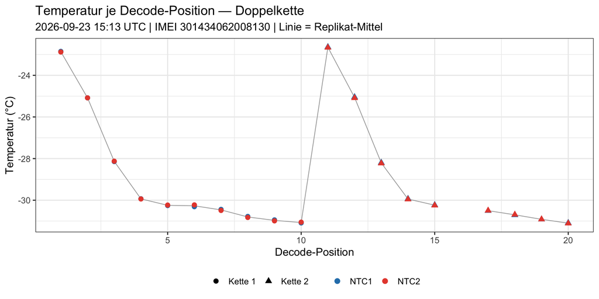

```r
long_ntc <- nodes |>
  select(position, chain, ntc1_C, ntc2_C) |>
  pivot_longer(c(ntc1_C, ntc2_C), names_to = "sensor", values_to = "temp_C") |>
  filter(!is.na(temp_C)) |>
  mutate(sensor = recode(sensor, ntc1_C = "NTC1", ntc2_C = "NTC2"))

ggplot(long_ntc, aes(position, temp_C)) +
  geom_line(data = nodes, aes(position, ntc_C), colour = "grey65", linewidth = 0.4) +
  geom_point(aes(colour = sensor, shape = chain), size = 2.6) +
  scale_colour_manual(values = c(NTC1 = "#2980b9", NTC2 = "#e74c3c")) +
  labs(title = sprintf("Temperatur je Decode-Position — %s", cfg$label),
       subtitle = sprintf("%s UTC | IMEI %s | Linie = Replikat-Mittel",
                          format(time_utc, "%Y-%m-%d %H:%M"), imei),
       x = "Decode-Position", y = "Temperatur (°C)", colour = NULL, shape = NULL) +
  theme_bw(base_size = 13) + theme(legend.position = "bottom")
```

## Tiefenprofil

Beide NTC-Kanäle (NTC1 / NTC2) gegen die Tiefe, je Kette. Oberfläche (0 m) oben, tief unten. **Farbe = Kette** (Kette 1 orange, Kette 2 blau), **Punktform = NTC-Kanal** (NTC1 / NTC2). **Links** der volle Bereich, **rechts** derselbe Plot ohne den obersten Sensor (1 m) im Zoom — der oberste Node ist deutlich wärmer und streckt sonst die Temperaturachse, sodass die Struktur der tiefen Sensoren nicht mehr auflösbar ist.

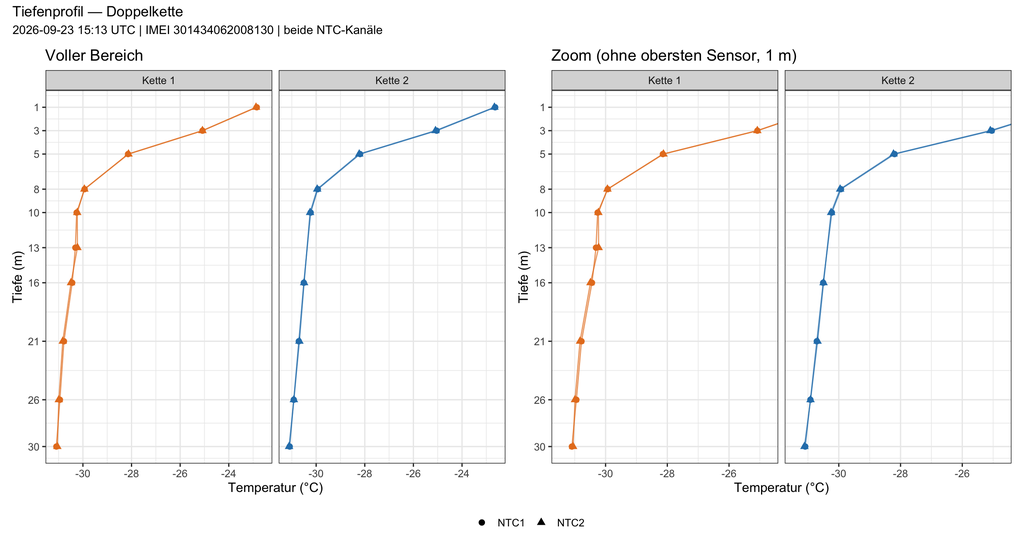

```r
# Einheitliche Ketten-Farben, in allen Tiefenprofil-Plots durchgehalten.
chain_cols <- c("Kette 1" = "#e67e22", "Kette 2" = "#2980b9")

prof_long <- nodes |>
  select(position, chain, depth_m, ntc1_C, ntc2_C) |>
  pivot_longer(c(ntc1_C, ntc2_C), names_to = "sensor", values_to = "temp_C") |>
  mutate(sensor = recode(sensor, ntc1_C = "NTC1", ntc2_C = "NTC2")) |>
  filter(!is.na(depth_m), !is.na(temp_C))

# Farbe = Kette, Punktform = NTC-Kanal, facettiert je Kette.
depth_profile <- function(df, ttl, xlim = NULL) {
  g <- ggplot(df, aes(temp_C, depth_m, colour = chain, shape = sensor)) +
    geom_path(aes(group = interaction(chain, sensor)), linewidth = 0.5, alpha = 0.7) +
    geom_point(size = 2.4) +
    scale_y_reverse(name = "Tiefe (m)", breaks = c(1, 3, 5, 8, 10, 13, 16, 21, 26, 30)) +
    scale_x_continuous(name = "Temperatur (°C)") +
    scale_colour_manual(values = chain_cols, guide = "none") +
    scale_shape_manual(values = c(NTC1 = 16, NTC2 = 17)) +
    facet_wrap(~ chain) +
    labs(title = ttl, shape = NULL) +
    theme_bw(base_size = 12) + theme(legend.position = "bottom")
  if (!is.null(xlim)) g <- g + coord_cartesian(xlim = xlim)
  g
}

# Zoom-Bereich: alle Sensoren AUSSER dem flachsten (obersten) Node.
deep <- prof_long |> filter(depth_m > min(depth_m))
xr   <- range(deep$temp_C, na.rm = TRUE); xr <- xr + c(-1, 1) * 0.05 * diff(xr)

p_full <- depth_profile(prof_long, "Voller Bereich")
p_zoom <- depth_profile(prof_long, "Zoom (ohne obersten Sensor, 1 m)", xlim = xr)

(p_full | p_zoom) +
  plot_annotation(title = sprintf("Tiefenprofil — %s", cfg$label),
                  subtitle = sprintf("%s UTC | IMEI %s | beide NTC-Kanäle",
                                     format(time_utc, "%Y-%m-%d %H:%M"), imei)) +
  plot_layout(guides = "collect") & theme(legend.position = "bottom")
```

### Beide Ketten übereinander (Mittel NTC1/NTC2)

Das **Replikat-Mittel** (NTC1/NTC2) beider Ketten in **einem** Panel übereinandergelegt, mit der gleichen Ketten-Farbgebung. So werden die beiden Bohrloch-Profile direkt vergleichbar. **Links** voller Bereich, **rechts** Zoom ohne den obersten Sensor (1 m).

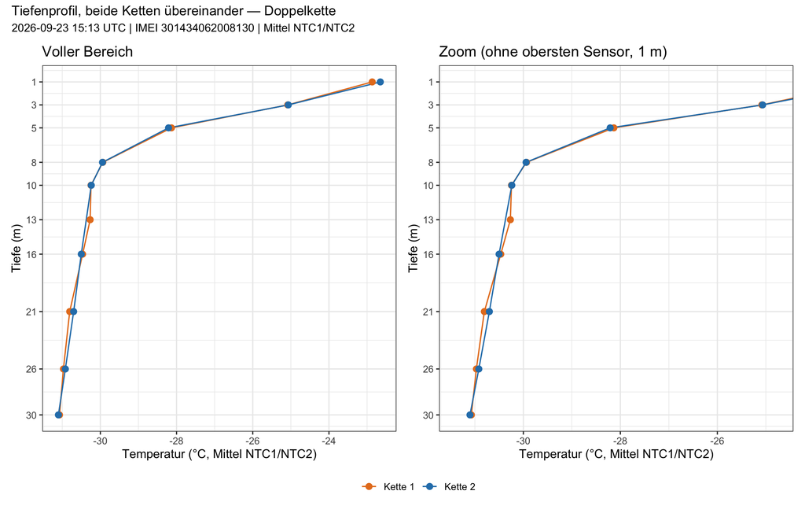

```r
prof_mean <- nodes |>
  select(chain, depth_m, ntc_C) |>
  filter(!is.na(depth_m), !is.na(ntc_C))

depth_mean_profile <- function(df, ttl, xlim = NULL) {
  g <- ggplot(df, aes(ntc_C, depth_m, colour = chain)) +
    geom_path(linewidth = 0.6) +
    geom_point(size = 2.6) +
    scale_y_reverse(name = "Tiefe (m)", breaks = c(1, 3, 5, 8, 10, 13, 16, 21, 26, 30)) +
    scale_x_continuous(name = "Temperatur (°C, Mittel NTC1/NTC2)") +
    scale_colour_manual(values = chain_cols) +
    labs(title = ttl, colour = NULL) +
    theme_bw(base_size = 12) + theme(legend.position = "bottom")
  if (!is.null(xlim)) g <- g + coord_cartesian(xlim = xlim)
  g
}

deep_m <- prof_mean |> filter(depth_m > min(depth_m))
xrm    <- range(deep_m$ntc_C, na.rm = TRUE); xrm <- xrm + c(-1, 1) * 0.05 * diff(xrm)

m_full <- depth_mean_profile(prof_mean, "Voller Bereich")
m_zoom <- depth_mean_profile(prof_mean, "Zoom (ohne obersten Sensor, 1 m)", xlim = xrm)

(m_full | m_zoom) +
  plot_annotation(title = sprintf("Tiefenprofil, beide Ketten übereinander — %s", cfg$label),
                  subtitle = sprintf("%s UTC | IMEI %s | Mittel NTC1/NTC2",
                                     format(time_utc, "%Y-%m-%d %H:%M"), imei)) +
  plot_layout(guides = "collect") & theme(legend.position = "bottom")
```